# PAC reanalysis: the endothelial subset

What the Zepp series supports, what it does not, and what to test next

Seonghwan Jun · Pang lab PAC project

2026-10-15

## Where we are

**Three documents since the last meeting**

1. **Analysis plan** (29 Sep). Six workstreams to extract self-renewal evidence from scRNA-seq; pre-registered support/against calls.
2. **EC subset reanalysis** (8 Oct, this talk). 23,895 vascular ECs, seven ages, states derived from the data alone. Optimal transport and RNA velocity from the original BAMs.
3. **Jinjiang’s audit** (12 Oct). PAC_2 / PAC_3 versus gCap with the original labels, after cell-cycle and complexity adjustment.

**Today**

- Walk through the EC subset results
- Cross-check them against the audit and an independent rough pass
- State what is now defensible, what is open, and how to close it

**The claim under test**

PACs are a lung-resident endothelial progenitor with robust **self-renewal**, peaking E12.5 to P7, giving rise to a CD34-high intermediate and then to arterial, venous and capillary ECs.

scRNA-seq cannot prove self-renewal. It can show that the state **divides**, **persists**, **has direction**, and **replicates**.

## How the subset was built

**Independent of the codebook.** Thresholds, panels and labels were derived from the data; Jinjiang’s codebook was used only afterwards as a comparison.

- **QC**: per age, cells kept within 3 median absolute deviations (MAD, a robust SD) of the median on log genes and log counts (both tails) and mitochondrial % (upper tail only, hard cap 20%). 69,302 cells, a strict subset of the codebook’s.
- **Endothelium**: whole-lung Leiden 1.0; cluster called EC when Pecam1, Cdh5, Cldn5 detected in ≥60% of cells and no non-EC lineage score >0.5 SD. Cycling clusters subclustered and rescued separately.
- **Cell cycle**: S/G2M regressed, ~200 cycle-correlated genes removed, Harmony on age. Cycling kept as a per-cell flag (95th percentile of P42).
- **States**: 12 Leiden clusters; named only where a published panel scored highest *and* its genes were in the cluster’s own top 50 de novo markers.

|  | cells |
| --- | --- |
| whole lung after QC | 69,302 |
| vascular EC | 23,895 |
| mature gCap | 10,276 |
| aCap | 4,521 |
| CD34-high immature gCap | 2,634 |
| immature EC | 2,255 |
| arterial | 2,250 |
| venous | 1,367 |
| lymphatic | 465 |
| unassigned (see later) | 127 |

Why the cycle has to be controlled: **97% of ECs cycle at E12.5, 5% at P42.** Uncorrected, the embedding sorts by proliferation, not identity.

## EC states on the cycle-controlled embedding

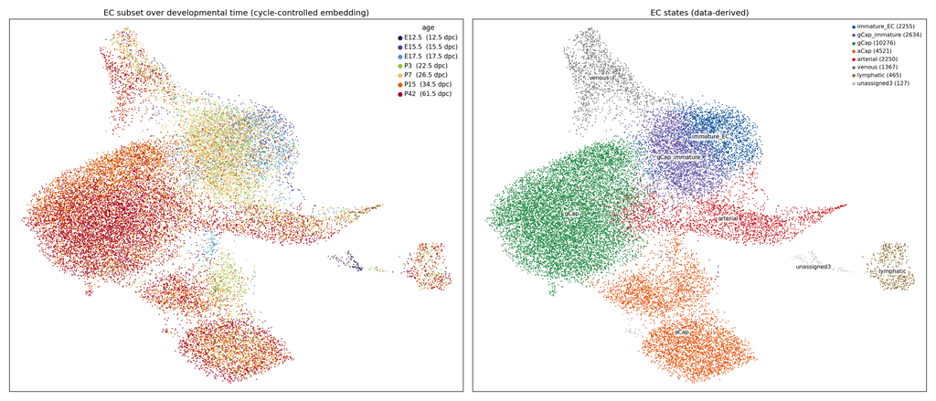

Left: age. Right: data-derived states. The two immature states sit between embryonic (upper right) and adult (lower left) territory.

## The same map, one age at a time

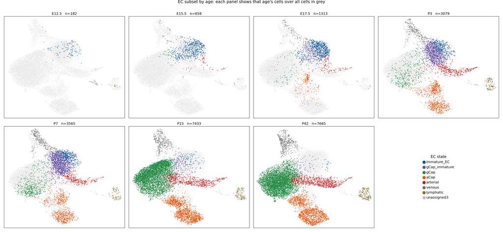

## Composition: the capillary compartment turns over between P7 and P15

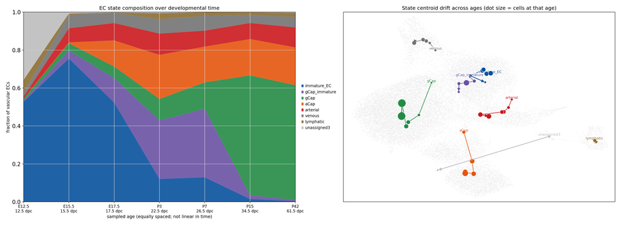

| state | E12.5 | E15.5 | E17.5 | P3 | P7 | P15 | P42 |
| --- | --- | --- | --- | --- | --- | --- | --- |
| immature EC | 53% | 76% | 52% | 12% | 13% | 1.5% | 0.4% |
| **CD34-high immature gCap** | 0.5% | 4% | 13% | **31%** | **36%** | 2% | 0.7% |
| mature gCap | 1% | 4% | 6% | 11% | 14% | 63% | 60% |
| aCap | 0% | 0.5% | 14% | 23% | 19% | 19% | 20% |
| arterial / venous | 1 / 2% | 7 / 7% | 9 / 5% | 11 / 8% | 8 / 8% | 9 / 4% | 11 / 6% |

Left: fraction of vascular ECs per state at each age. Right: each dot is a state’s centroid (mean UMAP position) at one age, dot size = cells of that state at that age, lines join consecutive ages E12.5 → P42 (arrowhead at P42). Lines trace where the state’s centre of mass sits over time; they are not lineage arrows. E12.5 and E15.5 rest on 182 and 658 cells: directional, not quantitative.

## Three things the composition says

- **aCap is specified early.** It reaches its adult share by P3 (23% vs 20% at P42) and stops changing. Alveolar capillary specification is essentially done before the immature gCap pool resolves.
- **The immature-to-mature gCap switch is late and abrupt.** CD34-high immature gCap is the largest single state at P7 (36%) and nearly gone at P15 (2%); mature gCap jumps 14% → 63% across the same step.
- **Arterial and venous are flat from E15.5.** Specified early, then scale with the tissue. Their centroids barely move; the gCap and aCap centroids travel far between E17.5 and P15.

## Where the cycling cells went

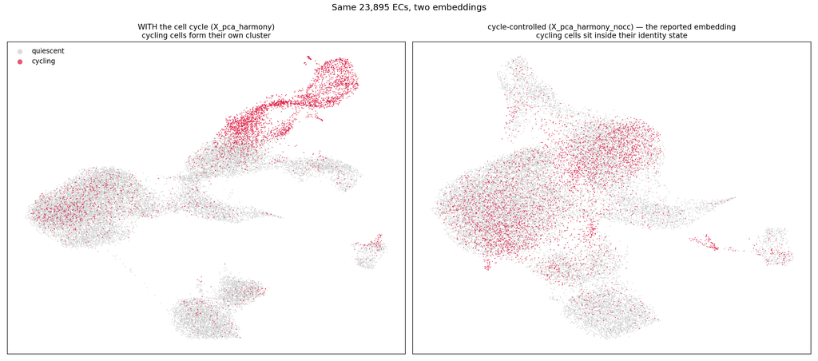

**What the figure is.** The same 23,895 ECs drawn twice, red = cycling, grey = quiescent. Both panels already have Harmony on age; the only difference is the cell-cycle correction.

**Left, cycle left in.** Cycling cells of *every* identity (gCap, immature EC, arterial, aCap) are pulled into one arm at the top right, because a few hundred S/G2M genes dominate the variance. Clustering this gives a “proliferating EC” cluster that is really a mixture.

**Right, cycle regressed.** S and G2M scores regressed, ~200 cycle-correlated genes removed, embedding rebuilt. The red cells no longer have their own territory; each sits inside the state it belongs to. The separation on the left was proliferation, not identity.

**Why it matters.** In the whole-lung clustering (all cell types, cycle left in), three clusters were large in the embryo, collapsed at P3 and rebounded at P7, which looked like a progenitor pool re-expanding. They were not PAC: two were cycling cells of every lineage pooled (clusters 1 and 10, S and G2M), the third was myofibroblasts (cluster 0, the P7 septation wave). Cycling is kept as a per-cell flag, so the next slide asks whether an EC-specific rebound survives, and where it sits.

## Proliferation dips at P3 and rebounds at P7, concentrated in the CD34-high pool

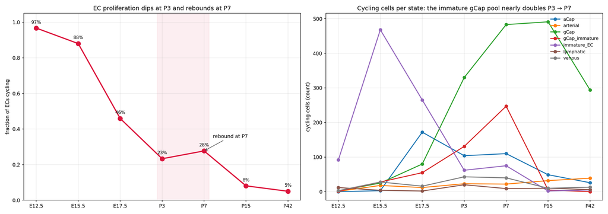

|  | P3 | P7 |
| --- | --- | --- |
| cycling, all EC | 23.3% | 27.7% |
| cycling CD34-high immature gCap, count | 131 | 247 |
| cycling share within that state | 13.8% | 19.2% |

The P7 wave is **not** a uniform return to embryonic behaviour. It sits in the CD34-high compartment, the PAC-relevant population. Cycling immature EC does the opposite: peaks at E15.5 (467 cells) and never recovers.

## Markers: which states are discrete cell types?

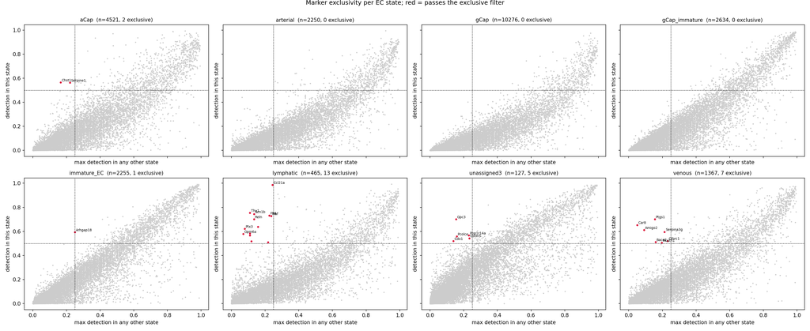

Exclusive = detected in ≥50% of the state, ≤25% of any other state, adj. p < 0.01, logFC > 0.5. Fold change alone fails here: ambient Sftpc is detected in 99.8% of gCap cells.

| state | cells | exclusive | best markers (in state → max elsewhere) |
| --- | --- | --- | --- |
| lymphatic | 465 | 13 | Ccl21a 99→24%, Thy1 75→11%, Flt4 73→22%, Prox1 58→11% |
| venous | 1,367 | 7 | Car8 65→5%, Ptgs1 70→16%, Amigo2 61→9% |
| aCap | 4,521 | 2 | Car4 93→37%, Emp2 97→48%, Hopx 83→33%, Apln 72→27% |
| arterial | 2,250 | 0 | Gja5 44→6%, Cxcl12 83→46%, Dll4 64→38% |
| immature EC | 2,255 | 1 | Arhgap18 59→25%; then haemoglobins (contamination) |
| **CD34-high immature gCap** | 2,634 | **0** | Tubb2b 70→49%, Peg3 57→43%, Mcam 51→37% |
| mature gCap | 10,276 | 0 | Lpl 40→22%; nothing else clears a 10-point gap |

- The de novo markers are the canonical ones (Prox1/Pdpn/Flt4; Gja5/Dll4/Efnb2; Car4/Hopx), found without being given any panel. That is the strongest evidence the states are real.
- Gja5 fails by dropout (44% in arterial), Car4 by continuum (37% outside aCap). Any sorting panel needs a second gene.
- **Mature gCap is defined by absence**: what a capillary EC looks like when it is not anything else.

## Two cautions before anyone quotes a marker

**Immature EC markers are partly contamination**

- After Arhgap18, the top markers are Hbb-bt, Hba-a1, Hbb-bs: erythrocyte ambient RNA, worst in the embryonic samples where that state lives.
- The cluster’s own top ten are ribosomal protein genes, so part of this state may be library complexity.

**No ambient correction has been applied yet.** Per-cell marker claims on ambient-prone genes are not reliable until it is.

**The 127-cell “unassigned” cluster is two things**

- 65 E12.5 cells: **mitotic embryonic lung mesenchyme** (Tbx4, Wnt2, Hoxb5, Gpc3 up; Pecam1 0.27 vs 1.35), not doublets. Entered via the cycling-cluster rescue.
- 62 postnatal cells: **genuine doublets** (1.5 to 2.6× RNA, Scrublet 0.23 to 0.38, dual EC + mesenchymal programmes).
- Both should leave the subset. The velocity PAGA graph was run before removal and needs re-running.

## Inside mature gCap: mostly technical structure, some biology

**Technical drivers, in order of size**

1. **Dissociation stress.** High immediate-early-gene fraction: 0% from E12.5 to P7, 12% at P15, **56% at P42**. Inflates any P15-vs-P42 difference.
2. **Ambient RNA.** Sftpc in 99.8% of gCap (median 11 UMIs), Scgb1a1 in 83%. Soup, not doublets.
3. **Doublets: not here.** Scrublet calls 0.1% in gCap.

Original subclusters were nearly age-locked; after cleaning, ARI 0.19 against the originals.

**What survives (12,910 gCap cells)**

| subpopulation | cells | markers |
| --- | --- | --- |
| core mature gCap | 2,164 | Ramp2, Tmem100, Hpgd, Cd36 |
| arterial-leaning | 1,450 | Cxcl12, Gja4, Id1, Aqp1 |
| angiogenic / tip-like | 1,262 | Plvap, Esm1, Dll4, Hey1 |
| cycling | 1,160 | Hmgb2, Top2a, Birc5 |
| aCap-leaning | 388 | Car4, Cd24a, Cd34, Emp2 |
| Vegfc subset | 372 | Vegfc, Thbd, Tspan8 |
| interferon / MHC-II | 143 / 48 | Isg15, Ifit1 / H2-Ab1, Cd74 |

**Does not affect the PAC window** (no stressed cells E17.5 to P7). It does affect the P7→P15 destination: “drains into mature gCap” now has at least three possible receivers.

## Two ways to get direction: RNA velocity vs optimal transport

**RNA velocity (scVelo)**, within one snapshot

- Input: spliced and unspliced read counts per gene, from the original BAMs.
- Logic: unspliced pre-mRNA precedes spliced mRNA. More unspliced than steady state means the gene is turning on; less means turning off. Summed over ~2,000 genes, each cell gets a vector predicting where it will be in a few hours.
- Direction comes from a **kinetic model of transcription**. Age labels are never used.
- Weaknesses: model assumptions (constant rates, one steady state per gene); noisy in strongly cycling cells; nuclear-retained genes like Malat1 create spurious velocity; projection onto UMAP can give coherent arrows pointing the wrong way in large terminal clusters.
- Also yields: latent time, velocity-directed PAGA, driver genes.

**Optimal transport (moscot / Waddington-OT)**, across snapshots

- Input: cells at age *t* and cells at age *t+1*, in the cycle-controlled embedding, plus a growth prior so dividing cells can map to more descendants.
- Logic: find the cheapest redistribution of the earlier population onto the later one. The result is a **coupling**: for each P3 cell, a probability distribution over the P7 cells it most plausibly became. The arrow is its expected displacement.
- Direction comes from **measured time**. No kinetic model.
- Weaknesses: assumes descendants are the cells that look most similar at the next age; blind to anything within one age; uninformative where a state is stationary; a coupling is a correspondence, not a lineage measurement.
- CellRank’s RealTimeKernel turns the coupling into a cell-to-cell transition matrix.

**The two share no inputs beyond the embedding.** Where they agree (immature EC → CD34-high immature gCap → mature gCap) the direction rests on two independent measurements. Where they disagree (inside mature gCap) neither is trusted alone.

## Trajectory from measured time: optimal transport

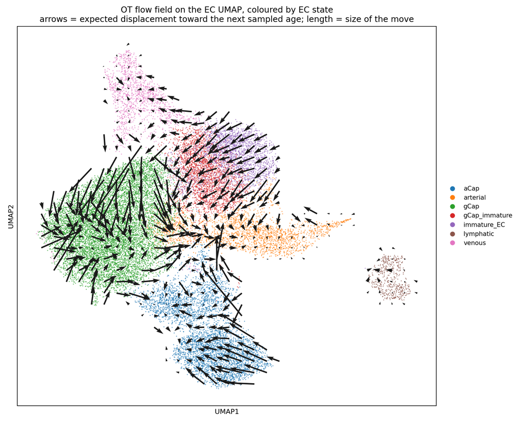

moscot couplings between adjacent ages (ε 1e-3, τ_a 0.95, growth prior). Each arrow is the expected displacement of a cell toward the next sampled age. Direction comes from real time, not a kinetic model.

## The same field coloured by age: arrows carry cells from younger into older territory

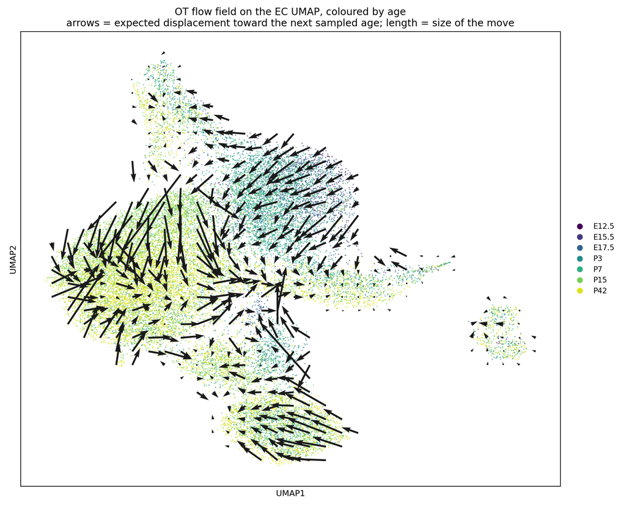

## Validating the couplings against the centroids

For each state and adjacent-age pair, cosine between mean OT displacement and the state’s observed centroid move.

- All 33 transitions: **70% positive, median +0.55**
- The 14 transitions where the centroid moves ≥0.5 units: **86% positive**
- Disagreements fall where nothing moves: at P3→P7 every centroid moves <0.43 units.

| state | step | move | cosine |
| --- | --- | --- | --- |
| mature gCap | P7→P15 | 2.06 | +0.94 |
| mature gCap | P15→P42 | 1.31 | +0.99 |
| immature EC | P7→P15 | 1.15 | +0.99 |
| CD34-high immature gCap | P7→P15 | 0.46 | +0.99 |
| aCap | P3→P7 | 0.38 | −0.98 (stationary) |

**Mean displacement per state and age**

| state | E17.5 | P3 | P7 | P15 |
| --- | --- | --- | --- | --- |
| CD34-high immature gCap | 1.00 | 0.72 | 1.59 | **3.17** |
| immature EC | 1.28 | 0.76 | 1.96 | 2.77 |
| mature gCap | 1.71 | 1.39 | 1.61 | 1.94 |
| aCap | 2.00 | 1.00 | 1.01 | 1.19 |
| arterial | 0.80 | 0.66 | 0.80 | 0.78 |
| venous | 0.49 | 0.56 | 0.69 | 0.81 |
| lymphatic | 0.48 | 0.45 | 0.28 | 0.30 |

**P3→P7 is local churn; P7→P15 is a long directed exit from the immature region.** The 149 CD34-high cells still present at P15 are pulled hardest toward the mature region.

## RNA velocity, measured independently from the BAMs

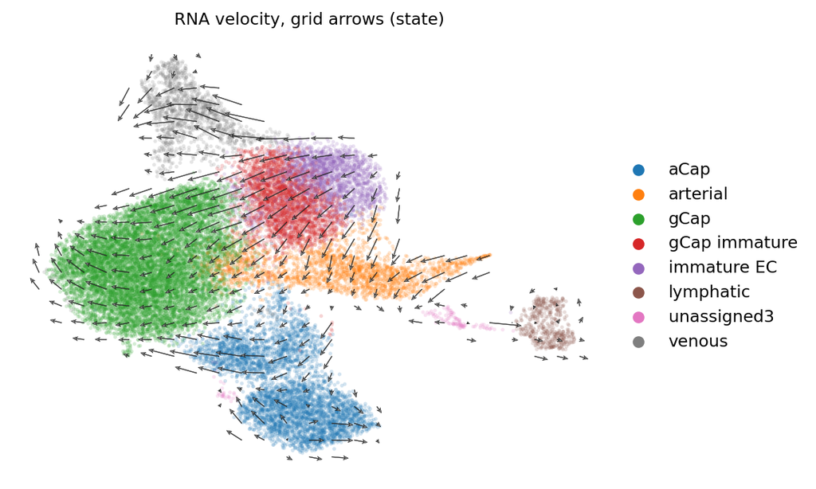

velocyto on the seven deposited BAMs (229.5 GB); 23,895 of 23,895 EC barcodes matched. 71% spliced / 24% unspliced / 5% ambiguous. scVelo stochastic mode, 2,000 HVGs, same cycle-controlled graph and UMAP as the OT analysis.

## Velocity and OT agree on the differentiation route, disagree inside mature gCap

Per-cell cosine, velocity vs OT displacement (16,128 cells; P42 excluded). Overall **median +0.26, 57% positive**.

| EC state | E17.5 | P3 | P7 | P15 | cells |
| --- | --- | --- | --- | --- | --- |
| immature EC | +0.74 | +0.10 | +0.88 | +0.12 | 2,224 |
| CD34-high immature gCap | +0.73 | −0.11 | +0.58 | +0.57 | 2,584 |
| venous | +0.51 | +0.20 | +0.76 | +0.33 | 943 |
| arterial | +0.60 | −0.02 | +0.63 | +0.20 | 1,444 |
| aCap | +0.36 | −0.29 | +0.31 | +0.24 | 2,994 |
| **mature gCap** | **−0.45** | **−0.63** | −0.08 | +0.14 | 5,645 |

- Agreement is strong wherever cells are actively differentiating, absent in the terminal capillary states.
- The gCap disagreement is **not** low confidence (velocity confidence 0.72, same as aCap). A coherent field pointing the wrong way is the signature of the UMAP projection in a large homogeneous terminal cluster.
- Stochastic and dynamical velocity agree with each other (median cosine +0.93). Dynamical mode sharpens, does not resolve, the gCap discrepancy.

**Honest reading:** two velocity modes and one OT field corroborate the trajectory *into* gCap; none resolves direction *within* mature gCap.

## Does the velocity field order the cells sensibly on its own?

**Check 1: latent time.** scVelo gives each cell one number, 0 to 1, for how far along it is, fitted from splicing kinetics. The model never sees the ages. Does the number rise with real age?

| age | E12.5 | E15.5 | E17.5 | P3 | P7 | P15 | P42 |
| --- | --- | --- | --- | --- | --- | --- | --- |
| mean latent time | 0.08 | 0.12 | 0.16 | 0.38 | 0.34 | 0.62 | 0.62 |

- Correlation with sampling age: **+0.55** (all cells). Could this just be proliferation falling with age? In non-cycling cells alone it is still **+0.45**, so no.
- Averaged per state: immature EC (0.12) → CD34-high immature gCap (0.26) → venous / lymphatic (0.5) → arterial (0.60) → mature gCap (0.62) → aCap (0.70). **aCap last was not imposed**; Car4-high aCap is a postnatal population.

**Check 2: the directed state graph (PAGA).** For each pair of states, how much velocity flow runs from A to B? Only two edges are strong.

| edge | no time prior | with latent-time prior |
| --- | --- | --- |
| immature EC → CD34-high immature gCap | **1.28** | **2.07** |
| CD34-high immature gCap → mature gCap | **0.54** | **0.60** |
| venous → gCap | 0.29 | — |
| CD34-high immature gCap → arterial | — | 0.17 |

- The latent-time prior can help orient edges but risks echoing check 1. With **no prior** the same two edges are still the strongest, so the direction is in the velocity itself.

**Conclusion.** Velocity alone says **immature EC → CD34-high immature gCap → mature gCap**, aCap terminal, arterial and venous side branches weak. Same route as optimal transport gave from measured time.

Not to quote: scVelo velocity_pseudotime (nine competing roots, orders immature EC after aCap); CellRank random walks (jump into the lymphatic island). Latent time, PAGA, grid arrows and streamlines are four views of the same velocity vectors; only OT is an independent measurement.

## Jinjiang’s audit (12 Oct): PAC_2 / PAC_3 vs gCap with the original labels

**Design.** Linked integer counts, CPTT; cases PAC_2 (287 / 316 cells at P3 / P7), PAC_3 (45 / 78); controls original capillary1 gCap, no PAC cells (1,177 / 1,549). Adjusted for linear + quadratic S/G2M, log depth, log genes; marker-supported-control sensitivity; both ages independently.

**The earlier 448 / 235 / 109 lists** were conserved Tier 1 genes (positive FC against every comparator, no effect or P threshold). No gene passed conserved Tier 2, 3 or 4.

| contrast | observed at both ages | after adjustment + sensitivity |
| --- | --- | --- |
| PAC_2 | 409 | **5** |
| PAC_3 | 85 | **16** |
| PAC_2+3 | 386 | **8** |
| PAC_1+2+3 | 681 | 8 |

**What survives.** H2afz and Rbm3 in both PAC_2 and PAC_3. PAC_3-preferential: Hmgn2, Hist1h2bc, Hist1h1c, H1f0, Hmgb1, Ptms. PAC_2: Dek, Nap1l1, Ptma (subtype specificity unresolved).

- **None is exclusive.** H2afz is in 83 to 92% of gCap already, Rbm3 in 98 to 99%. No candidate reaches ≥50% PAC / ≤20% every other EC state.
- **16 of 20 are in the broad proliferation-associated list.** PAC_2 is S phase (276/287 cells), PAC_3 is G2/M (32/45). Adjustment removes measured cycle score, not unmeasured proliferation programmes.
- Phase-matched pairs retain only 34 to 43% of PAC cells; no PAC_2 gene passes paired q < 0.05 at both ages.
- Depleted in PAC_3: Ehd4, Ldb2, Malat1.

**Their conclusion:** limited residual signal; does not establish a distinct PAC identity or independence from proliferation.

## Cross-validation: three analyses, one picture

| claim | EC report (de novo states) | Jinjiang’s audit (original labels) | independent rough pass (this week) |
| --- | --- | --- | --- |
| A proliferative CD34-high immature gCap state exists at P3/P7, peaks P7 | 31% → 36% of EC; largest state at P7 | PAC_1/2/3 = 597 / 841 cells; PAC_2 S-phase, PAC_3 G2/M | immature/gCap most proliferative compartment at both ages |
| EC proliferation dips at P3, rebounds at P7 | 23% → 28% (flag) | not addressed | 26% → 33% (phase); 15% → 30% (Mki67 or Top2a) |
| The rebound is concentrated in the CD34-high pool | cycling share in state 13.8% → 19.2% | PAC cell count 597 → 841 | cycling within immature/gCap 20% → 34% |
| No exclusive marker for the PAC / immature gCap state | 0 exclusive genes | best residuals H2afz, Rbm3, already in 83 to 99% of gCap | H2afz in 86 to 94%, Rbm3 in 98 to 99% of *non-cycling* immature/gCap |
| Residual PAC genes track proliferation | state defined on cycle-regressed embedding | 16 / 20 in proliferation list | Hmgn2 detected 88 to 91% cycling vs 49 to 70% non-cycling |
| Ambient RNA is heavy | Sftpc 99.8% of gCap | not addressed | Sftpc 99.5 to 100% of all EC; Hbb-bs 10% (P3) vs 65% (P7) |
| Canonical markers behave as described | Gja5 44→6%, Car4 93→37% | gCap controls: Gpihbp1 93 to 100%, Aplnr 70 to 93% | Gja5 36 to 39% → 2%; Car4 93 to 99% → 11 to 29% |
| Compartment shares | aCap 23 / 19%, arterial 11 / 8%, venous 8 / 8% | — | aCap 23 / 16% ✓; arterial 21 / 7%, venous 19 / 15% (crude max-score call over-assigns at P3) |

Rough pass: codebook QC (reproduces Jinjiang’s cell counts exactly), no doublet removal, no cycle regression, state = max program score. Agreement is order-of-magnitude, and that is the point: the main results do not depend on one pipeline.

## What can now be stated

1. **The PAC-relevant state is real and large but transient.** A CD34-high immature gCap compartment is 31 to 36% of lung ECs at P3 to P7 and under 2% by P15. Found de novo, with canonical markers for every neighbouring state recovered without supervision.
2. **It is the most proliferative EC compartment and carries the P7 proliferation wave.** Three pipelines agree on the P3→P7 rebound and on where it sits.
3. **Direction is immature EC → CD34-high immature gCap → mature gCap.** Supported by optimal transport (real time), RNA velocity (splicing kinetics), latent time and PAGA with no prior. Two independent measurements, four views.
4. **The state has no transcriptional identity beyond “immature gCap that is dividing”.** Zero exclusive markers; the audit’s residual genes (H2afz, Rbm3, histones, HMG proteins) are chromatin and proliferation-adjacent and present in most gCap cells.
5. **aCap, arterial and venous are specified early and are not downstream of the P3 to P7 pool in any detectable way.** Side branches to arterial and venous are weak (PAGA 0.17 or absent).
6. **Compartment-level persistence across P3→P7 is robust** (76 to 84% across an 18-setting sweep, 74% under Waddington-OT). This is the strongest available in-silico statement consistent with self-maintenance.

## What remains open, and how to verify each

| open question | why it matters | how to close it |
| --- | --- | --- |
| **Do dividing cells stay in the state?** “Cycling daughters stay cycling” ranged 2 to 40% across OT settings. Not quotable. | This is the in-silico analogue of symmetric self-renewal (plan WS1). | Identity-around-the-cycle analysis: tricycle angle, post-mitotic early-G1 cells (Ccng1/Cdkn1a high, Mki67 low) scored for immature vs mature programmes with cycle genes removed. Cheap; not yet run. |
| **Are the EC-report states Jinjiang’s PAC_1/2/3?** The audit uses original labels; the report uses de novo states. | Without a bridge, the two documents cannot be quoted together. | Cross-tabulate original PAC labels against the 12 Leiden states on the shared barcodes. One afternoon once the labels are shared. |
| **Where does the P7→P15 mass go?** Mature gCap resolves into core, arterial-leaning, tip-like. | Determines whether the PAC pool feeds one lineage or the whole capillary bed. | Re-run the P7→P15 coupling against the split gCap subsets. |
| **Direction inside mature gCap.** Velocity and OT disagree systematically. | Only matters if a claim about kinetics within gCap is made. | Compare in full expression space, not UMAP; or accept as unresolved. |
| **Ambient RNA.** No correction applied. | All per-cell marker claims and any sorting panel depend on it. | CellBender or SoupX on the raw matrices, then re-derive the marker table. |
| **Is the signal replicable?** One library per age; age and batch confounded. | A single-dataset result cannot carry a progenitor claim. | Hurskainen 2021 (replicates, hyperoxia) and Guo 2019 via the same pipeline (plan WS5). Hurskainen is the only place a between-animal test exists. |
| **Bst1 / Procr stem signatures.** First pass: Bst1 unexpressed, Procr highest in venous. | Would have let PAC inherit functional self-renewal evidence. | Score the full published DEG lists, not single markers (plan WS3). Expect a negative. |

## Mapping back to the plan

| workstream | status | result so far |
| --- | --- | --- |
| WS1 Identity around the cell cycle | **not started** | Highest priority remaining. OT-based “cycling daughters” proxy was unstable. |
| WS2 RNA velocity + CellRank | **done** | Velocity agrees with OT on route into gCap; latent time tracks age; PAGA edges stable without prior. CellRank projection artefact-prone in the immature region. |
| WS3 Stem/progenitor signature overlap | partial | Single markers negative for Bst1/Procr. Full gene lists and CytoTRACE pending. |
| WS4 Population kinetics | mostly done | Composition, cycling fraction and per-state cycling counts across seven ages. Two-compartment model not yet fitted. |
| WS5 Independent replication, hyperoxia | **not started** | Downloads not begun. |
| WS6 Sorting panel | blocked | Needs ambient correction first; mature gCap has no exclusive marker, CD34-high immature gCap has none. |

**Plan decisions still pending:** Jinjiang’s Seurat objects and PAC labels (needed for the label bridge); whether the wet-lab design can include a sparse inducible endothelial reporter.

## Proposed next two weeks

**Analysis**

1. Remove the 127 mesenchyme/doublet cells; re-run PAGA and the marker table.
2. Ambient correction (CellBender on raw h5), then re-derive markers.
3. WS1: identity around the cycle at P3 and P7.
4. Label bridge: original PAC_1/2/3 × de novo states.
5. P7→P15 coupling against split gCap.
6. Start Hurskainen download and processing.

**For the wet lab, stated now**

- Sort target: CD34-high immature gCap at P3 to P7. Current best enrichment panel remains GPIHBP1 + PCDH17 with APLN exclusion; add Cd34, Kit, Antxr2 as candidates once ambient-corrected.
- The decisive experiment is still **sparse inducible endothelial lineage labelling** with a clonal readout. Nothing in this dataset substitutes for it.
- What the data predict: labelled P3 immature gCap clones should contribute to mature gCap at P15, with little contribution to aCap, arterial or venous.

## Limits to state in any write-up

- Clonal descent cannot be inferred without barcodes or a reporter. Persistence across ages is compatible with, but does not demonstrate, self-renewal.
- A closed loop in UMAP or velocity is expected for any cycling population.
- One library per age. Cell-level p-values are not biological replication. Only Hurskainen offers between-animal statistics.
- Dissociation and capture bias differ across ages; pool sizes are relative.
- An OT coupling is an inferred correspondence, not a lineage measurement.
- No ambient correction yet; per-cell claims on ambient-prone genes are provisional.

Files: `/scratch/sjun6/jpang/PAC/results/v2/` (ec_states, de_markers, gcap_heterogeneity, trajectory, velocyto, velocity, velocity_trajectory); local cross-check `results/ws4_kinetics/crosscheck_ec_report_rough.csv`.